# FMH COPD Project

### Introduction

This project aims to discover the key care pathways for COPD.  
The techniques used in this project includes regression, classification and association analysis.

### About the data set

Population (791 beneficiaries):

- 2018_Q2 MSSP Assignment – Internally attributed to a MHP practice
- 65 or older as of 8/1/2016
- Part A or Part B claim with COPD diagnosis code in date range 8/1/2016 – 7/31/2017

Flu Vaccine: Y/N

- Between 8/1/2016 and 3/31/2017

Pneumococcal Vaccine: Y/N

- Vaccination any time after beneficiary turned 65

Medicare Annual Wellness Visit (AWV): Y/N

- Between 8/1/2016 and 7/31/2017

Transitions of Care Management / Chronic Care Management (TCM/CCM): Y/N

- Between 8/1/2016 and 7/31/2017

Inpatient Discharge (primary diagnosis of COPD): Count

- Between 8/1/2016 and 7/31/2017

Inpatient Readmission: Count

- Index visit between 8/1/2016 and 7/31/2017
  - Reviewed claims until 8/31/2017 to identify July 2017 readmissions

Emergency Department Visit (primary diagnosis of COPD): Count

- Between 8/1/2016 and 7/31/2017

```python
import matplotlib.pyplot as plt
import numpy as np
import pandas as pd
import seaborn as sns
#from matplotlib_venn import venn2
import matplotlib_venn
from sklearn.ensemble import RandomForestClassifier
from sklearn.metrics import confusion_matrix
from sklearn.model_selection import train_test_split
from sklearn.neural_network import MLPClassifier
from sklearn import linear_model
from sklearn import metrics
from sklearn import tree
import pydotplus
from sklearn.datasets import load_iris
import collections
from IPython.display import Image
from sklearn.metrics import confusion_matrix
from mlxtend.frequent_patterns import apriori
from mlxtend.frequent_patterns import association_rules
import networkx as nx
import re

from sklearn.tree import DecisionTreeClassifier, export_graphviz
from sklearn import tree
from sklearn.datasets import load_wine
from IPython.display import SVG
from graphviz import Source
from IPython.display import display
from scipy import stats

import matplotlib as mpl
```

```python
fmh = pd.read_csv("COPD_Analysis_File_2.txt", index_col="pt_id")
del fmh.index.name
```

```python
pd.set_option("display.max_rows", 1000)
fmh.head()
```

|  | Flu_Vac | Pneu_Vac | AWV | TCM_CCM | IP_DC_Count | Readmit_Count | ED_Visit_Count |
| --- | --- | --- | --- | --- | --- | --- | --- |
| 1 | 1 | 1 | 0 | 0 | 1 | 0 | 1 |
| 2 | 1 | 1 | 0 | 0 | 0 | 0 | 0 |
| 3 | 1 | 1 | 0 | 0 | 0 | 0 | 0 |
| 4 | 1 | 1 | 0 | 0 | 0 | 0 | 0 |
| 5 | 1 | 1 | 0 | 0 | 0 | 0 | 0 |

*AWV & TCM_CCM will be combine together as "Preventive Care"*

```python
fmh["Preventive_Care"] = fmh.AWV | fmh.TCM_CCM
fmh = fmh.drop(["AWV", "TCM_CCM"], axis=1)
cols = ["Flu_Vac", "Pneu_Vac", "Preventive_Care", "IP_DC_Count", "Readmit_Count", "ED_Visit_Count"]
fmh = fmh.ix[:, cols]
```

```python
fmh.head()
```

|  | Flu_Vac | Pneu_Vac | Preventive_Care | IP_DC_Count | Readmit_Count | ED_Visit_Count |
| --- | --- | --- | --- | --- | --- | --- |
| 1 | 1 | 1 | 0 | 1 | 0 | 1 |
| 2 | 1 | 1 | 0 | 0 | 0 | 0 |
| 3 | 1 | 1 | 0 | 0 | 0 | 0 |
| 4 | 1 | 1 | 0 | 0 | 0 | 0 |
| 5 | 1 | 1 | 0 | 0 | 0 | 0 |

```python
fmh.info()
```

```
<class 'pandas.core.frame.DataFrame'>
Int64Index: 791 entries, 1 to 791
Data columns (total 6 columns):
Flu_Vac            791 non-null int64
Pneu_Vac           791 non-null int64
Preventive_Care    791 non-null int64
IP_DC_Count        791 non-null int64
Readmit_Count      791 non-null int64
ED_Visit_Count     791 non-null int64
dtypes: int64(6)
memory usage: 43.3 KB
```

**Features**: Flu_Vac, Pneu_Vac, Preventive Care (NOTE: these are boolean)  
**Class labels**: IP_DC_Count, Readmit_Count, ED_Visit_Count (NOTE: these are **not** boolean)

### Visualization of the basic information

```python
#Turn into boolean, True = has inpatient
def make_bool(myseries, index_num):
    for index, value in myseries.iteritems():
        if value == 0:
            fmh.ix[index, index_num] = False
        else:
            fmh.ix[index, index_num] = True

#Turn into boolean, True means no in patient, no readmission, no emergency vist
def make_bool2(myseries, index_num):
    for index, value in myseries.iteritems():
        if value == 0:
            fmh.ix[index, index_num] = True
        else:
            fmh.ix[index, index_num] = False
```

```python
fmh["IP_DC"] = 0
make_bool(fmh["IP_DC_Count"], 6)
fmh["Readmit"] = 0
make_bool(fmh["Readmit_Count"], 7)
fmh["ED_Visit"] = 0
make_bool(fmh["ED_Visit_Count"], 8)
fmh["No_IP"] = 0
make_bool2(fmh["IP_DC_Count"], 9)
fmh["No_Readmit"] = 0
make_bool2(fmh["Readmit_Count"], 10)
fmh["No_ED"] = 0
make_bool2(fmh["ED_Visit_Count"], 11)
```

[output not shown]

```python
output = []
for i, r in fmh[["IP_DC", "Readmit", "ED_Visit"]].iterrows():
        total_count = r.astype(int).sum()
        #print(total_count)
        if total_count != 0:
            #print("True")
            output.append(True)
        else:
            output.append(False)

output = np.array(output)

fmh["Has_Bad_Outcome"] = output

output2=[]
for i, r in fmh[["IP_DC", "Readmit", "ED_Visit"]].iterrows():
        total_count = r.astype(int).sum()
        #print(total_count)
        if total_count != 0:
            #print("True")
            output2.append(False)
        else:
            output2.append(True)

fmh["No_Bad_Outcome"] = output2
```

```python
fmh.head()
```

|  | Flu_Vac | Pneu_Vac | Preventive_Care | IP_DC_Count | Readmit_Count | ED_Visit_Count | IP_DC | Readmit | ED_Visit | No_IP | No_Readmit | No_ED | Has_Bad_Outcome | No_Bad_Outcome |
| --- | --- | --- | --- | --- | --- | --- | --- | --- | --- | --- | --- | --- | --- | --- |
| 1 | 1 | 1 | 0 | 1 | 0 | 1 | True | False | True | False | True | False | True | False |
| 2 | 1 | 1 | 0 | 0 | 0 | 0 | False | False | False | True | True | True | False | True |
| 3 | 1 | 1 | 0 | 0 | 0 | 0 | False | False | False | True | True | True | False | True |
| 4 | 1 | 1 | 0 | 0 | 0 | 0 | False | False | False | True | True | True | False | True |
| 5 | 1 | 1 | 0 | 0 | 0 | 0 | False | False | False | True | True | True | False | True |

```python
# Turn all columns into integers (bool)
fmh_numeric = fmh.astype(int)
fmh_numeric.head()
```

|  | Flu_Vac | Pneu_Vac | Preventive_Care | IP_DC_Count | Readmit_Count | ED_Visit_Count | IP_DC | Readmit | ED_Visit | No_IP | No_Readmit | No_ED | Has_Bad_Outcome | No_Bad_Outcome |
| --- | --- | --- | --- | --- | --- | --- | --- | --- | --- | --- | --- | --- | --- | --- |
| 1 | 1 | 1 | 0 | 1 | 0 | 1 | 1 | 0 | 1 | 0 | 1 | 0 | 1 | 0 |
| 2 | 1 | 1 | 0 | 0 | 0 | 0 | 0 | 0 | 0 | 1 | 1 | 1 | 0 | 1 |
| 3 | 1 | 1 | 0 | 0 | 0 | 0 | 0 | 0 | 0 | 1 | 1 | 1 | 0 | 1 |
| 4 | 1 | 1 | 0 | 0 | 0 | 0 | 0 | 0 | 0 | 1 | 1 | 1 | 0 | 1 |
| 5 | 1 | 1 | 0 | 0 | 0 | 0 | 0 | 0 | 0 | 1 | 1 | 1 | 0 | 1 |

# not useful

set_flu = set(np.array(fmh[fmh["Flu_Vac"]==1].index)) set_pneu = set(np.array(fmh[fmh["Pneu_Vac"]==1].index)) set_prev = set(np.array(fmh[fmh["Preventive_Care"]==1].index)) set_ip = set(np.array(fmh[fmh["IP_DC"]==1].index)) set_re = set(np.array(fmh[fmh["Readmit"]==1].index)) set_ed = set(np.array(fmh[fmh["ED_Visit"]==1].index))

# intersection of flu_var and ip_dc, etc

flu_ip = list(set_flu.intersection(set_ip)) flu_re = list(set_flu.intersection(set_re)) flu_ed = list(set_flu.intersection(set_ed))

pneu_ip = list(set_pneu.intersection(set_ip)) pneu_re = list(set_pneu.intersection(set_re)) pneu_ed = list(set_pneu.intersection(set_ed))

prev_ip = list(set_prev.intersection(set_ip)) prev_re = list(set_prev.intersection(set_re)) prev_ed = list(set_prev.intersection(set_ed))

```python
fmh.head()
```

|  | Flu_Vac | Pneu_Vac | Preventive_Care | IP_DC_Count | Readmit_Count | ED_Visit_Count | IP_DC | Readmit | ED_Visit | No_IP | No_Readmit | No_ED | Has_Bad_Outcome | No_Bad_Outcome |
| --- | --- | --- | --- | --- | --- | --- | --- | --- | --- | --- | --- | --- | --- | --- |
| 1 | 1 | 1 | 0 | 1 | 0 | 1 | True | False | True | False | True | False | True | False |
| 2 | 1 | 1 | 0 | 0 | 0 | 0 | False | False | False | True | True | True | False | True |
| 3 | 1 | 1 | 0 | 0 | 0 | 0 | False | False | False | True | True | True | False | True |
| 4 | 1 | 1 | 0 | 0 | 0 | 0 | False | False | False | True | True | True | False | True |
| 5 | 1 | 1 | 0 | 0 | 0 | 0 | False | False | False | True | True | True | False | True |

```python
# Table of Flu_Vac vs IP_DC
flu_ip = pd.crosstab(index=fmh["IP_DC"],
                           columns=fmh["Flu_Vac"])

flu_ip.index= ["No_IP","Yes_IP"]

flu_ip.columns=["No_Flu","Yes_Flu"]
#flu_ip

pneu_ip = pd.crosstab(index=fmh["IP_DC"],
                           columns=fmh["Pneu_Vac"])

pneu_ip.index= ["No_IP","Yes_IP"]

pneu_ip.columns=["No_Pneu","Yes_Pneu"]
pneu_ip
```

|  | No_Pneu | Yes_Pneu |
| --- | --- | --- |
| No_IP | 131 | 531 |
| Yes_IP | 24 | 105 |

```python
def make_freq_table(series1, series2):
    table = pd.crosstab(index=series1,
                           columns=series2)
    return table
```

```python
make_freq_table(fmh["IP_DC"], fmh["Preventive_Care"])
```

| Preventive_Care IP_DC | 0 | 1 |
| --- | --- | --- |
| False | 519 | 143 |
| True | 73 | 56 |

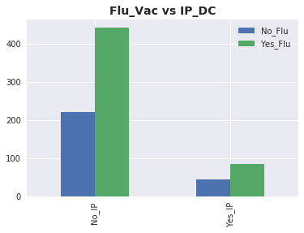

```python
flu_ip.plot(kind="bar")
plt.title("Flu_Vac vs IP_DC", fontweight="bold", fontsize=14)
plt.show()
```

from mpl_toolkits.mplot3d import axes3d style.use('ggplot')

fig = plt.figure() ax1 = fig.add_subplot(111, projection='3d')

x3 = [1,2,3,4,5,6,7,8,9,10] y3 = [5,6,7,8,2,5,6,3,7,2] z3 = np.zeros(10)

dx = np.ones(10) dy = np.ones(10) dz = [1,2,3,4,5,6,7,8,9,10]

ax1.bar3d(x3, y3, z3, dx, dy, dz)

ax1.set_xlabel('x axis') ax1.set_ylabel('y axis') ax1.set_zlabel('z axis')

plt.show()

```python
import pandas as pd
import scipy.stats as scs


def categories(series):
    return range(int(series.min()), int(series.max()) + 1)


def chi_square_of_df_cols(df, col1, col2):
    df_col1, df_col2 = df[col1], df[col2]

    result = [[sum((df_col1 == cat1) & (df_col2 == cat2))
               for cat2 in categories(df_col2)]
              for cat1 in categories(df_col1)]

    return scs.chi2_contingency(result)


#test_df = pd.read_csv('test_data_for_chi_square.csv')
print(chi_square_of_df_cols(fmh, 'Flu_Vac', 'IP_DC'))
```

```
(0.0082724182553183, 0.9275300676036707, 1, array([[220.94563843,  43.05436157],
       [441.05436157,  85.94563843]]))
```

```python
fmh_copy=fmh[["Flu_Vac", "Pneu_Vac", "Preventive_Care", "IP_DC", "Readmit", "ED_Visit"]]
fmh_copy = fmh_copy.astype(int)
yes = fmh_copy.sum().values
no = (fmh_copy == 0).sum().values
no
```

```
array([264, 155, 592, 662, 751, 730])
```

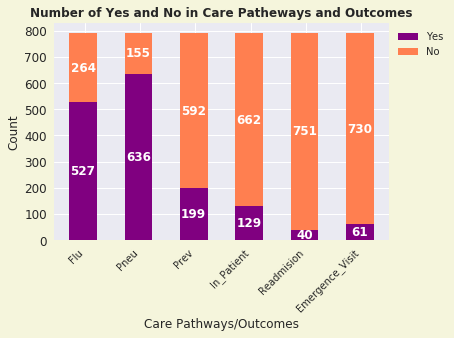

```python
fig = plt.figure(facecolor="beige")

ax = fig.add_subplot(1, 1, 1)
bar_width = 0.5
bar_l = np.arange(1,7)
tick_pos = [i + (bar_width / 16) for i in bar_l]

ax1 = ax.bar(bar_l, yes, width=bar_width, label="Yes", color="purple")
ax2 = ax.bar(bar_l, no, bottom=yes, width=bar_width, label="No", color="coral")
ax.set_ylabel("Count", fontsize=12)
ax.set_xlabel("Care Pathways/Outcomes", fontsize=12)
ax.legend(loc="best", bbox_to_anchor=(1, 1))
#plt.xticks(tick_pos, ["Flu", "Pneu", "Prev", "In_Patient",
                     # "Readmision", "Emergence_Visit"], rotation=45)
plt.yticks(fontsize=12)
labels=["Flu", "Pneu", "Prev", "In_Patient", "Readmision", "Emergence_Visit"]
ax.set_xticks(tick_pos)
ax.set_xticklabels(labels, rotation = 45, ha="right")

for r1, r2 in zip(ax1, ax2):
    h1 = r1.get_height()
    h2 = r2.get_height()
    plt.text(r1.get_x() + r1.get_width() / 2., h1 / 2., "%d" % h1,
             ha="center", va="center", color="white", fontsize=12, fontweight="bold")
    plt.text(r2.get_x() + r2.get_width() / 2., h1 + h2 / 2., "%d" % h2,
             ha="center", va="center", color="white", fontsize=12, fontweight="bold")

plt.title("Number of Yes and No in Care Patheways and Outcomes", fontsize=12, fontweight="bold")
plt.show()
```

```python
fmh1 = fmh.sort_values('Flu_Vac', ascending=False)
fmh_by_flu = fmh1[fmh1["Flu_Vac"]==1]
fmh2 = fmh1[fmh1["Flu_Vac"]==0]
fmh_by_pneu = fmh2[fmh2["Pneu_Vac"]==1]
fmh3 = fmh2[fmh2["Pneu_Vac"]==0]
fmh_by_prev = fmh3[fmh3["Preventive_Care"]==1]
fmh4 = fmh3[fmh3["Preventive_Care"]==0]
fmh_by_ip = fmh4[fmh4["IP_DC"]==True]
fmh5 = fmh4[fmh4["IP_DC"]==False]
fmh_by_re = fmh5[fmh5["Readmit"]==True]
fmh6 = fmh5[fmh5["Readmit"]==False]
fmh_by_em = fmh6[fmh6["ED_Visit"]==True]
fmh_rest = fmh6[fmh6["ED_Visit"]==False]
dfs = [fmh_by_flu, fmh_by_pneu, fmh_by_prev, fmh_by_ip, fmh_by_re, fmh_by_em, fmh_rest]
sorted_fmh = pd.concat(dfs)
sorted_fmh = sorted_fmh[["Flu_Vac", "Pneu_Vac", "Preventive_Care", "IP_DC", "Readmit", "ED_Visit"]]
sorted_fmh = sorted_fmh.astype(int)
sorted_fmh.shape
```

```
(791, 6)
```

```python
fmh_rest.shape
```

```
(77, 14)
```

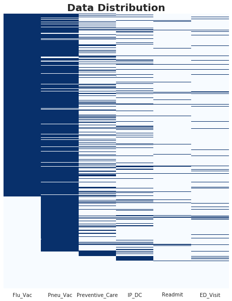

```python
fig = plt.figure(figsize=(8,10))
ax=sns.heatmap(sorted_fmh, xticklabels="auto", yticklabels=False, cbar=False, cmap="Blues")
plt.title("Data Distribution", fontweight="bold", fontsize=20)
#sns.set(font_scale=1.5)
plt.show()
```

# pick_columns = ['Flu_Vac','Pneu_Vac','Preventive_Care','No_IP','No_Readmit','No_ED',]

fig = plt.figure(figsize=(8,200)) ax=sns.heatmap(fmh[fmh.columns[0:6]], xticklabels=True, yticklabels=True, linecolor= "grey", cbar=False, cmap="Blues", vmin=0, vmax=1, linewidths=1) plt.title("Data Distribution", fontweight="bold", fontsize=20) ax.hlines(range(fmh[fmh.columns[0:6]].astype(int).shape[0]),*ax.get_xlim(), color="grey") ax.vlines(range(fmh[fmh.columns[0:6]].astype(int).shape[1]),*ax.get_ylim(), color="grey") plt.show()

```python
set1 =set(np.array(fmh[fmh["Flu_Vac"]==True].index))
set2 = set(np.array(fmh[fmh["Pneu_Vac"]==True].index))
set3= set(np.array(fmh[fmh["Preventive_Care"]==True].index))
#set1
```

```python
# calcualte the number of no bad outcome for each intersection.
fmh_venn = fmh.astype(int)
no_bad_outcome = fmh_venn[["No_Bad_Outcome"]]

# 1
just_prev_index = list(set1.union(set2, set3) - set1 - set2)
just_prev = no_bad_outcome.iloc[just_prev_index].sum()[0]

#2
just_pneu_index = list(set1.union(set2, set3) - set3 - set1)
just_pneu = no_bad_outcome.iloc[just_pneu_index].sum()[0]

#3
prev_pneu_index = list(set2.intersection(set3)- set1)
prev_pneu = no_bad_outcome.iloc[prev_pneu_index].sum()[0]

#4
just_flu_index = list(set1.union(set2, set3) - set3 - set2)
just_flu = no_bad_outcome.iloc[just_flu_index].sum()[0]

#5
prev_flu_index = list(set1.intersection(set3)- set2)
prev_flu = no_bad_outcome.iloc[prev_flu_index].sum()[0]

#6
pneu_flu_index = list(set1.intersection(set2)- set3)
pneu_flu = no_bad_outcome.iloc[pneu_flu_index[0:341]].sum()[0]

#7
intersection_index = list(set1.intersection(set2, set3))
intersection = no_bad_outcome.iloc[intersection_index].sum()[0]

no_bad_total =[just_prev, just_pneu, prev_pneu, just_flu, prev_flu, pneu_flu, intersection]
```

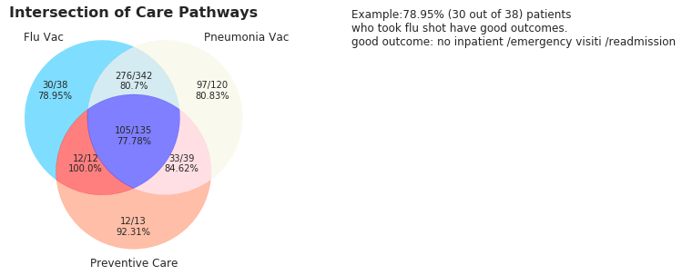

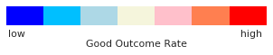

```python
fig = plt.figure(figsize=(5,5))
fig.add_subplot(1, 1, 1)

v = matplotlib_venn.venn3_unweighted([set1, set2, set3],
      set_labels = ('Flu Vac', "Pneumonia Vac", 'Preventive Care'), alpha = 0.5)
plt.title("Intersection of Care Pathways", fontweight="bold", fontsize=16)

#colors=["red", "pink", "green", "grey", "orange", "purple", "blue"]
colors=["coral", "beige", "pink", "deepskyblue", "red", "lightblue", "blue"]

for i in range(7):
    b = bin(i+1)[2:].zfill(3)
    v.get_patch_by_id(b).set_color(colors[i])
    intersect_text = v.get_label_by_id(b)
    intersect_num = re.findall(r"'(.*?)'", str(intersect_text), re.DOTALL)
    for ele in intersect_num:
        ele1=str(no_bad_total[i])+"/"+ele
        ele2 = str(round((no_bad_total[i]/float(ele))*100, 2))+"%"
        ele=ele1+ "\n" +ele2
        v.get_label_by_id(b).set_text(ele)
        v.get_label_by_id(b).set_size(10)

v.get_label_by_id('A').set_size(12)
v.get_label_by_id('B').set_size(12)
v.get_label_by_id('C').set_size(12)

#v.get_label_by_id('001').set_text("12")
plt.text(1.2, 0.5,
         "Example:78.95% (30 out of 38) patients \nwho took flu shot have good outcomes.\ngood outcome: no inpatient /emergency visiti /readmission")

fig = plt.figure(figsize=(4, 2))
ax3 = fig.add_axes([4, 3, 1, 0.15])
colors=["blue","deepskyblue","lightblue", "beige", "pink", "coral", "red"]

cmap = mpl.colors.ListedColormap(colors)
cmap.set_over((1., 0., 0.))
cmap.set_under((0., 0., 1.))

bounds = [-1.5,-1., -.5, 0., .5, 1.,1.5, 2]
norm = mpl.colors.BoundaryNorm(bounds, cmap.N)
cb3 = mpl.colorbar.ColorbarBase(ax3, cmap=cmap,
                                norm=norm,
                                extendfrac='auto',
                                orientation='horizontal')
cb3.set_ticks([])

cb3.set_label('low                                                                    high \nGood Outcome Rate')

plt.show()
```

**Interpretation:**

1. **135 patients took all three care pathways. 77.78% of them didn't have COPD recurance**
2. 38 patients only took flu vaccine. 30 out of them (78.95%) didn't have COPD recurance.
3. 120 patients only took pneumonia vaccine.
4. 13 patients only took preventive care (AWV & TCM_CCM)
5. 342 patients only took flu vaccine and pneumonia vaccine.
6. 12 patients only took flu vaccine and preventive care.
7. 39 patients only took pneumonia vaccine and preventive care.

```python
fmh.columns
```

```
Index([u'Flu_Vac', u'Pneu_Vac', u'Preventive_Care', u'IP_DC_Count',
       u'Readmit_Count', u'ED_Visit_Count', u'IP_DC', u'Readmit', u'ED_Visit',
       u'No_IP', u'No_Readmit', u'No_ED', u'Has_Bad_Outcome',
       u'No_Bad_Outcome'],
      dtype='object')
```

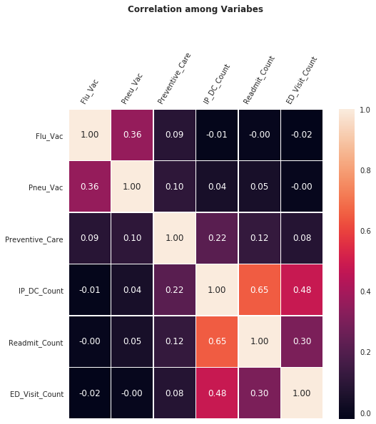

```python
sns.set(font_scale=1)
correlations = fmh[fmh.columns[0:6]].corr()
f,ax1 = plt.subplots(figsize=(8, 8))
sns.heatmap(correlations, annot=True, linewidths=.5, fmt= '.2f',ax=ax1)
ax1.xaxis.tick_top()
ax1.set_xticklabels(fmh[fmh.columns[0:6]].columns, rotation=60)
ax1.set_yticklabels(fmh[fmh.columns[0:6]].columns)
plt.title("Correlation among Variabes", y=1.3, fontweight="bold")
plt.show()
```

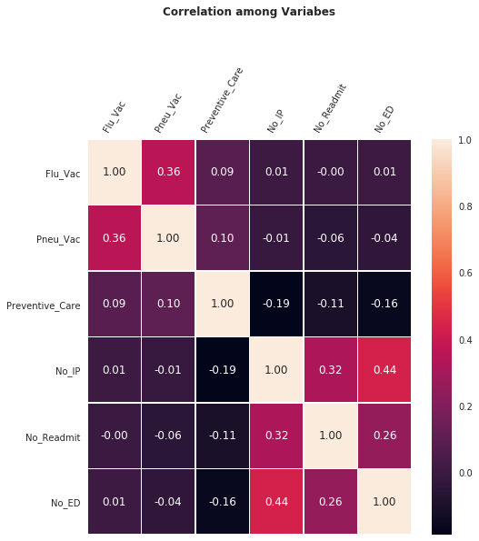

```python
sns.set(font_scale=1)
correlations = (fmh[['Flu_Vac', 'Pneu_Vac', 'Preventive_Care', 'No_IP', 'No_Readmit', 'No_ED']].astype(int)).corr()
f,ax1 = plt.subplots(figsize=(8, 8))
sns.heatmap(correlations, annot=True, linewidths=.5, fmt= '.2f',ax=ax1)
ax1.xaxis.tick_top()
ax1.set_xticklabels((fmh[['Flu_Vac', 'Pneu_Vac', 'Preventive_Care', 'No_IP', 'No_Readmit', 'No_ED']].astype(int)).columns,
                    rotation=60)
ax1.set_yticklabels((fmh[['Flu_Vac', 'Pneu_Vac', 'Preventive_Care', 'No_IP', 'No_Readmit', 'No_ED']].astype(int)).columns)
plt.title("Correlation among Variabes", y=1.3, fontweight="bold")
plt.show()
```

**Interpretation**  
From the heatmap, we can see, the correlation among predictor variables and bad outcome class labels as well as the no bad outcome class labels are not very strong.

### Regression Model

This project trys to make a regression model to predict the class labels since they are numeric.  
The project trys on the in-patient discharge first.

```python
x =fmh.iloc[:, 0:3].values
y_ip = fmh.iloc[:, 3].values
y_re = fmh.iloc[:, 4].values
y_ed = fmh.iloc[:, 5].values
```

```python
x_train, x_test, y_ip_trian, y_ip_test = train_test_split(x, y_ip, random_state=123)
```

```python
reg_ip = linear_model.BayesianRidge().fit(x, y_ip)
reg_pre_ip = reg_ip.predict(x_test)
reg_ip_df = pd.DataFrame()
reg_ip_df["True"] = y_ip_test
reg_ip_df["Prediction"] = reg_pre_ip
reg_ip_df.head()
```

|  | True | Prediction |
| --- | --- | --- |
| 0 | 0 | 0.169772 |
| 1 | 0 | 0.103897 |
| 2 | 0 | 0.596258 |
| 3 | 1 | 0.533949 |
| 4 | 0 | 0.232082 |

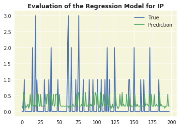

```python
ax=reg_ip_df.plot()
ax.set_facecolor("beige")
plt.title("Evaluation of the Regression Model for IP", fontweight="bold")
ax.legend(bbox_to_anchor=[1,1])
plt.show()
```

```python
rmse_ip = np.sqrt(metrics.mean_squared_error(y_ip_test,reg_pre_ip))
rmse_ip
```

```
0.5807589272593271
```

**Interpretation:**  
The root mean square error of the regression model is 0.58. Overal the model predicts the trend of the test data set, but the accuracy is not good. The reason why this model is not good enough might be that this class label, although it is numeric, it is not continous, and most of the data is 0. In this case, it may be better to build a classification model.

### Classification Models

```python
fmh.info()
```

```
<class 'pandas.core.frame.DataFrame'>
Int64Index: 791 entries, 1 to 791
Data columns (total 14 columns):
Flu_Vac            791 non-null int64
Pneu_Vac           791 non-null int64
Preventive_Care    791 non-null int64
IP_DC_Count        791 non-null int64
Readmit_Count      791 non-null int64
ED_Visit_Count     791 non-null int64
IP_DC              791 non-null bool
Readmit            791 non-null bool
ED_Visit           791 non-null bool
No_IP              791 non-null bool
No_Readmit         791 non-null bool
No_ED              791 non-null bool
Has_Bad_Outcome    791 non-null bool
No_Bad_Outcome     791 non-null bool
dtypes: bool(8), int64(6)
memory usage: 89.4 KB
```

```python
# No inpatient, no readmission, no emergency visit
y_ip_cl = fmh.iloc[:, 9].values
y_re_cl = fmh.iloc[:, 10].values
y_ed_cl = fmh.iloc[:, 11].values
```

```python
x_ip_cl_train, x_ip_cl_test, y_ip_cl_train, y_ip_cl_test = train_test_split(x, y_ip_cl, random_state=12)
x_re_cl_train, x_re_cl_test, y_re_cl_train, y_re_cl_test = train_test_split(x, y_re_cl, random_state=12)
x_ed_cl_train, x_ed_cl_test, y_ed_cl_train, y_ed_cl_test = train_test_split(x, y_ed_cl, random_state=12)
```

```python
clf_ip = tree.DecisionTreeClassifier(criterion = "entropy", random_state = 100,
            max_depth = 3, min_samples_leaf = 2)
clf_ip = clf_ip.fit(x_ip_cl_train,y_ip_cl_train)

clf_re = tree.DecisionTreeClassifier(criterion = "entropy", random_state = 100,
            max_depth = 3, min_samples_leaf = 2)
clf_re = clf_ip.fit(x_re_cl_train,y_re_cl_train)

clf_ed = tree.DecisionTreeClassifier(criterion = "entropy", random_state = 100,
            max_depth = 3, min_samples_leaf = 2)
clf_ed = clf_ip.fit(x_ed_cl_train,y_ed_cl_train)
```

```python
graph = Source(tree.export_graphviz(clf_ip, out_file=None, feature_names = ["Flu", "Pneu", "Prev"],
                                    class_names=["False", "True"], filled = True))
display(SVG(graph.pipe(format='svg')))
```

```
Fontconfig warning: ignoring C.UTF-8: not a valid language tag
```

[figure not shown]

```python
graph = Source(tree.export_graphviz(clf_re, out_file=None, feature_names = ["Flu", "Pneu", "Prev"],
                                    class_names=["False", "True"], filled = True))
display(SVG(graph.pipe(format='svg')))
```

```
Fontconfig warning: ignoring C.UTF-8: not a valid language tag
```

[figure not shown]

```python
graph = Source(tree.export_graphviz(clf_ed, out_file=None, feature_names = ["Flu", "Pneu", "Prev"],
                                    class_names=["False", "True"], filled = True))
display(SVG(graph.pipe(format='svg')))
```

```
Fontconfig warning: ignoring C.UTF-8: not a valid language tag
```

[figure not shown]

```python
ip_predict = clf_ip.predict(x_ip_cl_test)
re_predict = clf_re.predict(x_re_cl_test)
ed_predict = clf_ed.predict(x_ed_cl_test)
```

```python
cm_ip = confusion_matrix(y_ip_cl_test, ip_predict)
cm_re = confusion_matrix(y_re_cl_test, re_predict)
cm_ed = confusion_matrix(y_ed_cl_test, ed_predict)
```

```python
cm_ip_df = pd.DataFrame(cm_ip, columns=["Has In-Patient", "No In-Patient"], index=["Has In-Patient", "No In-Patient"])
cm_re_df = pd.DataFrame(cm_re, columns=["Has In-Patient", "No In-Patient"], index=["Has In-Patient", "No In-Patient"])
cm_ed_df = pd.DataFrame(cm_ed, columns=["Has In-Patient", "No In-Patient"], index=["Has In-Patient", "No In-Patient"])
#cm_ip_df.index.name="Fact"
print(cm_ip_df)
print(cm_re_df)
print(cm_ed_df)
```

```
                Has In-Patient  No In-Patient
Has In-Patient               0             32
No In-Patient                0            166
                Has In-Patient  No In-Patient
Has In-Patient               0              6
No In-Patient                0            192
                Has In-Patient  No In-Patient
Has In-Patient               0             18
No In-Patient                0            180
```

**Interpretation:**  
The classifers don't work well at tall as they fail to capture the bad outcome. It may because the class labels have small amount of "Yes". The data is not balance, so it is hard to make an useful classification model.

# Association Analysis

```python
fmh_asso = fmh.drop(["IP_DC_Count", "Readmit_Count", "ED_Visit_Count", 'No_IP', 'No_Readmit', 'No_ED', 'Has_Bad_Outcome',
       'No_Bad_Outcome'], axis=1)
```

```python
frequent_itemsets = apriori(fmh_asso, min_support=0.02, use_colnames=True)
rules = association_rules(frequent_itemsets, metric="lift", min_threshold=1)
rules.shape
```

```
(190, 9)
```

```python
def uppack_frozenset(myseries, mylist):
    index_list = []
    items=[]
    for index, value in myseries.iteritems():
        for item in value:
            if (len(value)==1) & (item in mylist):
                index_list.append(index)
            elif item in mylist:
                items.append(index)
        if len(items) == len(value):
            index_list.append(index)
        items=[]
    return index_list
```

```python
predictors = ["Preventive_Care", "Flu_Vac", "Pneu_Vac"]
predictors_index = uppack_frozenset(rules.antecedents, predictors)
class_labels = ["IP_DC", "Readmit", "ED_Visit"]
class_labels_index = uppack_frozenset(rules.consequents, class_labels)
good_index = list(set(predictors_index) & set(class_labels_index))
good_results = rules.iloc[good_index, :].sort_values(by='confidence', ascending=False).reset_index(drop=True)
```

**Below are rules with the features as "antecedents" and class labels as "consequents".**

```python
good_results
```

|  | antecedents | consequents | antecedent support | consequent support | support | confidence | lift | leverage | conviction |
| --- | --- | --- | --- | --- | --- | --- | --- | --- | --- |
| 0 | (Pneu_Vac, Preventive_Care) | (IP_DC) | 0.219975 | 0.163085 | 0.063211 | 0.287356 | 1.762007 | 0.027337 | 1.174381 |
| 1 | (Preventive_Care) | (IP_DC) | 0.251580 | 0.163085 | 0.070796 | 0.281407 | 1.725527 | 0.029768 | 1.164658 |
| 2 | (Pneu_Vac, Preventive_Care, Flu_Vac) | (IP_DC) | 0.170670 | 0.163085 | 0.042984 | 0.251852 | 1.544301 | 0.015150 | 1.118649 |
| 3 | (Preventive_Care, Flu_Vac) | (IP_DC) | 0.185841 | 0.163085 | 0.045512 | 0.244898 | 1.501661 | 0.015204 | 1.108347 |
| 4 | (Pneu_Vac) | (IP_DC) | 0.804046 | 0.163085 | 0.132743 | 0.165094 | 1.012323 | 0.001616 | 1.002407 |
| 5 | (Pneu_Vac, Flu_Vac) | (IP_DC) | 0.603034 | 0.163085 | 0.098609 | 0.163522 | 1.002681 | 0.000264 | 1.000523 |
| 6 | (Pneu_Vac, Preventive_Care) | (ED_Visit) | 0.219975 | 0.077118 | 0.035398 | 0.160920 | 2.086678 | 0.018434 | 1.099874 |
| 7 | (Preventive_Care) | (ED_Visit) | 0.251580 | 0.077118 | 0.037927 | 0.150754 | 1.954856 | 0.018525 | 1.086708 |
| 8 | (Preventive_Care, Flu_Vac) | (ED_Visit) | 0.185841 | 0.077118 | 0.026549 | 0.142857 | 1.852459 | 0.012217 | 1.076696 |
| 9 | (Pneu_Vac, Preventive_Care, Flu_Vac) | (ED_Visit) | 0.170670 | 0.077118 | 0.024020 | 0.140741 | 1.825015 | 0.010859 | 1.074044 |
| 10 | (Pneu_Vac, Preventive_Care) | (ED_Visit, IP_DC) | 0.219975 | 0.055626 | 0.029077 | 0.132184 | 2.376306 | 0.016841 | 1.088219 |
| 11 | (Preventive_Care) | (ED_Visit, IP_DC) | 0.251580 | 0.055626 | 0.030341 | 0.120603 | 2.168113 | 0.016347 | 1.073888 |
| 12 | (Preventive_Care, Flu_Vac) | (ED_Visit, IP_DC) | 0.185841 | 0.055626 | 0.020228 | 0.108844 | 1.956710 | 0.009890 | 1.059718 |
| 13 | (Pneu_Vac, Preventive_Care) | (Readmit) | 0.219975 | 0.050569 | 0.022756 | 0.103448 | 2.045690 | 0.011632 | 1.058981 |
| 14 | (Preventive_Care) | (Readmit) | 0.251580 | 0.050569 | 0.022756 | 0.090452 | 1.788693 | 0.010034 | 1.043850 |
| 15 | (Pneu_Vac) | (ED_Visit) | 0.804046 | 0.077118 | 0.065740 | 0.081761 | 1.060212 | 0.003734 | 1.005057 |
| 16 | (Pneu_Vac, Flu_Vac) | (ED_Visit) | 0.603034 | 0.077118 | 0.048040 | 0.079665 | 1.033027 | 0.001536 | 1.002767 |
| 17 | (Pneu_Vac, Flu_Vac) | (ED_Visit, IP_DC) | 0.603034 | 0.055626 | 0.036662 | 0.060797 | 1.092958 | 0.003118 | 1.005506 |
| 18 | (Pneu_Vac) | (ED_Visit, IP_DC) | 0.804046 | 0.055626 | 0.048040 | 0.059748 | 1.074114 | 0.003315 | 1.004385 |
| 19 | (Flu_Vac) | (ED_Visit, IP_DC) | 0.666245 | 0.055626 | 0.037927 | 0.056926 | 1.023374 | 0.000866 | 1.001379 |
| 20 | (Pneu_Vac) | (Readmit) | 0.804046 | 0.050569 | 0.045512 | 0.056604 | 1.119340 | 0.004852 | 1.006397 |
| 21 | (Pneu_Vac, Flu_Vac) | (Readmit) | 0.603034 | 0.050569 | 0.031606 | 0.052411 | 1.036426 | 0.001111 | 1.001944 |
| 22 | (Flu_Vac) | (Readmit) | 0.666245 | 0.050569 | 0.034134 | 0.051233 | 1.013140 | 0.000443 | 1.000700 |
| 23 | (Pneu_Vac) | (IP_DC, Readmit) | 0.804046 | 0.034134 | 0.031606 | 0.039308 | 1.151584 | 0.004160 | 1.005386 |
| 24 | (Pneu_Vac, Flu_Vac) | (IP_DC, Readmit) | 0.603034 | 0.034134 | 0.021492 | 0.035639 | 1.044103 | 0.000908 | 1.001561 |
| 25 | (Flu_Vac) | (IP_DC, Readmit) | 0.666245 | 0.034134 | 0.022756 | 0.034156 | 1.000633 | 0.000014 | 1.000022 |

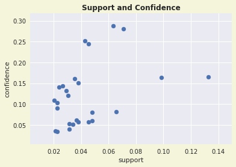

```python
fig = plt.figure(facecolor="beige")
plt.scatter(good_results["support"], good_results["confidence"])
plt.xlabel("support")
plt.ylabel("confidence")
plt.title("Support and Confidence", fontdict={'fontweight':"bold"})
plt.show()
```

```python
def draw_graph(rules, rules_to_show):
    G1 = nx.DiGraph()
    color_map=[]
    N = 50
    #seed=12
    colors = np.random.rand(N)
    strs=['R0', 'R1', 'R2', 'R3', 'R4', 'R5', 'R6', 'R7', 'R8', 'R9', 'R10', 'R11']

    for i in range (rules_to_show):
        G1.add_nodes_from(["R"+str(i+1)])

        for a in rules.iloc[i, 0]:
            G1.add_nodes_from([a])
            G1.add_edge(a, "R"+str(i+1), color=colors[i] , weight = 2)

        for c in rules.iloc[i, 1]:
            G1.add_nodes_from([c])
            G1.add_edge("R"+str(i+1), c, color=colors[i],  weight=2)

    for node in G1:
        found_a_string = False
        for item in strs:
            if node==item:
                found_a_string = True
        if found_a_string:
            color_map.append('grey')
        else:
            color_map.append('coral')

    edges = G1.edges()

    colors = [G1[u][v]['color'] for u,v in edges]
    weights = [G1[u][v]['weight'] for u,v in edges]

    pos = nx.spring_layout(G1, k=16, scale=1)
    nx.draw(G1, pos, edges=edges, node_color = color_map,edge_color=colors, width=weights,
            font_size=12, with_labels=False, arrowsize=20)

    for p in pos:  # raise text positions
        pos[p][1] += 0.12
    nx.draw_networkx_labels(G1, pos)

    s="   Support  confidence\n"
    for i, val in rules[["support", "confidence"]].iterrows():
         s += ("R"+str(i+1)+"   " +str(round(val[0]*100, 2))+"%" +
                "   "+str(round(val[1]*100, 2))+"%"+"\n")

    plt.text(1, 1, s=s)
    plt.show()
```

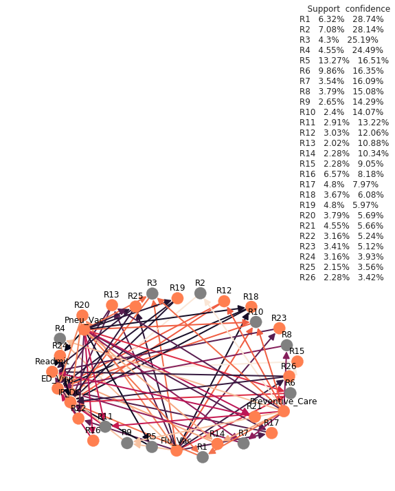

```python
draw_graph(good_results, good_results.shape[0])
```

**Interpretation**  
Rule No.1: It is 28.74% confident that if a patient takes preventive care and pneumonia vaccine, he will only have 6.32% chance to get in-patient.  
It may sound better when the concequent is NO in-patient/NO readmission /NO emergency visit. So the project works on it below.

```python
drop_col = [3, 4, 5, 6, 7, 8]
fmh_asso2 = fmh.drop(['IP_DC_Count','Readmit_Count','ED_Visit_Count','IP_DC','Readmit',
    'ED_Visit', 'Has_Bad_Outcome',
    'No_Bad_Outcome'], axis=1)
fmh_asso2.head()
```

|  | Flu_Vac | Pneu_Vac | Preventive_Care | No_IP | No_Readmit | No_ED |
| --- | --- | --- | --- | --- | --- | --- |
| 1 | 1 | 1 | 0 | False | True | False |
| 2 | 1 | 1 | 0 | True | True | True |
| 3 | 1 | 1 | 0 | True | True | True |
| 4 | 1 | 1 | 0 | True | True | True |
| 5 | 1 | 1 | 0 | True | True | True |

```python
frequent_itemsets2 = apriori(fmh_asso2, min_support=0.0001, use_colnames=True)
rules2 = association_rules(frequent_itemsets2, metric="lift", min_threshold=1)
rules2
```

|  | antecedents | consequents | antecedent support | consequent support | support | confidence | lift | leverage | conviction |
| --- | --- | --- | --- | --- | --- | --- | --- | --- | --- |
| 0 | (No_Readmit, Pneu_Vac, No_IP) | (Flu_Vac) | 0.657396 | 0.666245 | 0.494311 | 0.751923 | 1.128598 | 0.056324 | 1.345368 |
| 1 | (No_Readmit, Pneu_Vac, Flu_Vac) | (No_IP) | 0.571429 | 0.836915 | 0.494311 | 0.865044 | 1.033610 | 0.016074 | 1.208431 |
| 2 | (No_Readmit, No_IP, Flu_Vac) | (Pneu_Vac) | 0.547408 | 0.804046 | 0.494311 | 0.903002 | 1.123074 | 0.054170 | 2.020197 |
| 3 | (Pneu_Vac, No_IP, Flu_Vac) | (No_Readmit) | 0.504425 | 0.949431 | 0.494311 | 0.979950 | 1.032144 | 0.015394 | 2.522124 |
| 4 | (No_Readmit, Pneu_Vac) | (No_IP, Flu_Vac) | 0.758534 | 0.558786 | 0.494311 | 0.651667 | 1.166218 | 0.070453 | 1.266642 |
| 5 | (No_Readmit, Flu_Vac) | (Pneu_Vac, No_IP) | 0.632111 | 0.671302 | 0.494311 | 0.782000 | 1.164900 | 0.069973 | 1.507788 |
| 6 | (Pneu_Vac, No_IP) | (No_Readmit, Flu_Vac) | 0.671302 | 0.632111 | 0.494311 | 0.736347 | 1.164900 | 0.069973 | 1.395349 |
| 7 | (No_IP, Flu_Vac) | (No_Readmit, Pneu_Vac) | 0.558786 | 0.758534 | 0.494311 | 0.884615 | 1.166218 | 0.070453 | 2.092710 |
| 8 | (No_Readmit) | (Pneu_Vac, No_IP, Flu_Vac) | 0.949431 | 0.504425 | 0.494311 | 0.520639 | 1.032144 | 0.015394 | 1.033825 |
| 9 | (Pneu_Vac) | (No_Readmit, No_IP, Flu_Vac) | 0.804046 | 0.547408 | 0.494311 | 0.614780 | 1.123074 | 0.054170 | 1.174891 |
| 10 | (No_IP) | (No_Readmit, Pneu_Vac, Flu_Vac) | 0.836915 | 0.571429 | 0.494311 | 0.590634 | 1.033610 | 0.016074 | 1.046916 |
| 11 | (Flu_Vac) | (No_Readmit, Pneu_Vac, No_IP) | 0.666245 | 0.657396 | 0.494311 | 0.741935 | 1.128598 | 0.056324 | 1.327592 |
| 12 | (No_Readmit, Preventive_Care, Pneu_Vac, No_IP,... | (No_ED) | 0.122630 | 0.922882 | 0.117573 | 0.958763 | 1.038879 | 0.004400 | 1.870101 |
| 13 | (Preventive_Care, Pneu_Vac, No_ED, No_IP, Flu_... | (No_Readmit) | 0.122630 | 0.949431 | 0.117573 | 0.958763 | 1.009829 | 0.001144 | 1.226296 |
| 14 | (No_Readmit, Preventive_Care, Pneu_Vac, No_ED,... | (No_IP) | 0.136536 | 0.836915 | 0.117573 | 0.861111 | 1.028911 | 0.003304 | 1.174210 |
| 15 | (No_Readmit, Preventive_Care, No_ED, No_IP, Fl... | (Pneu_Vac) | 0.128951 | 0.804046 | 0.117573 | 0.911765 | 1.133972 | 0.013890 | 2.220818 |
| 16 | (No_Readmit, Preventive_Care, Pneu_Vac, No_ED,... | (Flu_Vac) | 0.145386 | 0.666245 | 0.117573 | 0.808696 | 1.213811 | 0.020710 | 1.744627 |
| 17 | (Preventive_Care, Pneu_Vac, No_IP, Flu_Vac) | (No_Readmit, No_ED) | 0.127686 | 0.891277 | 0.117573 | 0.920792 | 1.033116 | 0.003769 | 1.372630 |
| 18 | (No_Readmit, Pneu_Vac, No_IP, Flu_Vac) | (Preventive_Care, No_ED) | 0.494311 | 0.213654 | 0.117573 | 0.237852 | 1.113258 | 0.011961 | 1.031750 |
| 19 | (Pneu_Vac, No_ED, No_IP, Flu_Vac) | (No_Readmit, Preventive_Care) | 0.493047 | 0.228824 | 0.117573 | 0.238462 | 1.042116 | 0.004752 | 1.012655 |
| 20 | (No_Readmit, Pneu_Vac, No_ED, Flu_Vac) | (Preventive_Care, No_IP) | 0.534766 | 0.180784 | 0.117573 | 0.219858 | 1.216138 | 0.020896 | 1.050086 |
| 21 | (No_Readmit, Preventive_Care, No_IP, Flu_Vac) | (Pneu_Vac, No_ED) | 0.135272 | 0.738306 | 0.117573 | 0.869159 | 1.177234 | 0.017701 | 2.000090 |
| 22 | (Preventive_Care, No_ED, No_IP, Flu_Vac) | (No_Readmit, Pneu_Vac) | 0.134008 | 0.758534 | 0.117573 | 0.877358 | 1.156651 | 0.015923 | 1.968881 |
| 23 | (No_Readmit, Preventive_Care, No_ED, Flu_Vac) | (Pneu_Vac, No_IP) | 0.149178 | 0.671302 | 0.117573 | 0.788136 | 1.174040 | 0.017429 | 1.551454 |
| 24 | (No_Readmit, Preventive_Care, Pneu_Vac, No_IP) | (No_ED, Flu_Vac) | 0.151707 | 0.615676 | 0.117573 | 0.775000 | 1.258778 | 0.024170 | 1.708105 |
| 25 | (Preventive_Care, Pneu_Vac, No_ED, No_IP) | (No_Readmit, Flu_Vac) | 0.150442 | 0.632111 | 0.117573 | 0.781513 | 1.236353 | 0.022476 | 1.683799 |
| 26 | (No_Readmit, Preventive_Care, Pneu_Vac, No_ED) | (No_IP, Flu_Vac) | 0.171934 | 0.558786 | 0.117573 | 0.683824 | 1.223766 | 0.021498 | 1.395466 |
| 27 | (No_Readmit, Preventive_Care, No_ED, No_IP) | (Pneu_Vac, Flu_Vac) | 0.168142 | 0.603034 | 0.117573 | 0.699248 | 1.159550 | 0.016178 | 1.319912 |
| 28 | (Pneu_Vac, No_IP, Flu_Vac) | (No_Readmit, Preventive_Care, No_ED) | 0.504425 | 0.201011 | 0.117573 | 0.233083 | 1.159550 | 0.016178 | 1.041818 |
| 29 | (No_Readmit, Pneu_Vac, Flu_Vac) | (Preventive_Care, No_ED, No_IP) | 0.571429 | 0.173198 | 0.117573 | 0.205752 | 1.187956 | 0.018602 | 1.040987 |

[output cut: 404 more lines]

```python
predictors_index2 = uppack_frozenset(rules2.antecedents, predictors)
class_labels2 = ["No_IP", "No_Readmit", "No_ED", "No_Bad_Outcome", "Has_Bad_Outcome"]
class_labels_index2 = uppack_frozenset(rules2.consequents, class_labels2)
good_index2 = list(set(predictors_index2) & set(class_labels_index2))
good_results2 = rules2.iloc[good_index2, :].sort_values(by=['support','confidence'], ascending=False).reset_index(drop=True)
good_results2
```

|  | antecedents | consequents | antecedent support | consequent support | support | confidence | lift | leverage | conviction |
| --- | --- | --- | --- | --- | --- | --- | --- | --- | --- |
| 0 | (Flu_Vac) | (No_ED) | 0.666245 | 0.922882 | 0.615676 | 0.924099 | 1.001318 | 0.000810 | 1.016024 |
| 1 | (Flu_Vac) | (No_IP) | 0.666245 | 0.836915 | 0.558786 | 0.838710 | 1.002144 | 0.001195 | 1.011125 |
| 2 | (Flu_Vac) | (No_Readmit, No_IP) | 0.666245 | 0.820480 | 0.547408 | 0.821632 | 1.001403 | 0.000767 | 1.006456 |
| 3 | (Flu_Vac) | (No_IP, No_ED) | 0.666245 | 0.815424 | 0.546144 | 0.819734 | 1.005287 | 0.002872 | 1.023914 |
| 4 | (Flu_Vac) | (No_Readmit, No_IP, No_ED) | 0.666245 | 0.801517 | 0.534766 | 0.802657 | 1.001422 | 0.000759 | 1.005774 |
| 5 | (Pneu_Vac, Flu_Vac) | (No_IP, No_ED) | 0.603034 | 0.815424 | 0.493047 | 0.817610 | 1.002681 | 0.001319 | 1.011988 |

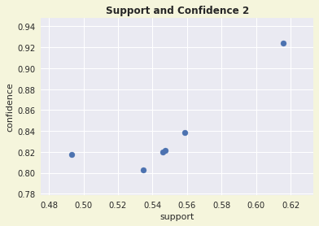

```python
fig = plt.figure(facecolor="beige")
plt.scatter(good_results2["support"], good_results2["confidence"])
plt.xlabel("support")
plt.ylabel("confidence")
plt.title("Support and Confidence 2", fontdict={'fontweight':"bold"})
plt.show()
```

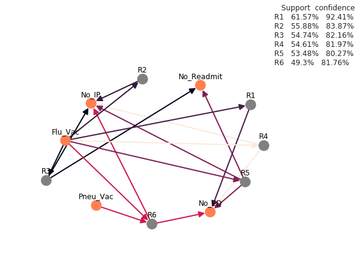

```python
draw_graph(good_results2, good_results2.shape[0])
```

**Interpretation:**  
Rule No.1: If a patient takes flu vaccine, it is 92.41% confident that he/she has 61.57% chance not going to the emergency room.  
Rule No.2: If a patient takes flu vaccine, it is 83.87% confident that he/she has 55.88% chance not getting in-patient.  
Rule No.3: If a patient takes flu vaccine, it is 82.16% confident that he/she has 54.74% chance not getting in-patient or readmission.  
Rule No.6: If a patient takes flu vaccine and pneunomia vaccine, it is 81.76% confident that he/she has 49.3% chance not getting in-patient or going to emergency room.

```python
fmh.columns
```

```
Index([u'Flu_Vac', u'Pneu_Vac', u'Preventive_Care', u'IP_DC_Count',
       u'Readmit_Count', u'ED_Visit_Count', u'IP_DC', u'Readmit', u'ED_Visit',
       u'No_IP', u'No_Readmit', u'No_ED', u'Has_Bad_Outcome',
       u'No_Bad_Outcome'],
      dtype='object')
```

```python
#drop_col = [3, 4, 5, 6, 7, 8]
fmh_asso3 = fmh.drop(['IP_DC_Count','Readmit_Count','ED_Visit_Count','IP_DC','Readmit',
    'ED_Visit', u'No_IP', u'No_Readmit', u'No_ED', u'Has_Bad_Outcome'], axis=1)
#fmh_asso3.head()

frequent_itemsets3 = apriori(fmh_asso3, min_support=0.001, use_colnames=True)
rules3 = association_rules(frequent_itemsets3, metric="lift", min_threshold=1)
rules3.head()
```

|  | antecedents | consequents | antecedent support | consequent support | support | confidence | lift | leverage | conviction |
| --- | --- | --- | --- | --- | --- | --- | --- | --- | --- |
| 0 | (No_Bad_Outcome) | (Flu_Vac) | 0.801517 | 0.666245 | 0.534766 | 0.667192 | 1.001422 | 0.000759 | 1.002846 |
| 1 | (Flu_Vac) | (No_Bad_Outcome) | 0.666245 | 0.801517 | 0.534766 | 0.802657 | 1.001422 | 0.000759 | 1.005774 |
| 2 | (Pneu_Vac, Preventive_Care) | (Flu_Vac) | 0.219975 | 0.666245 | 0.170670 | 0.775862 | 1.164529 | 0.024113 | 1.489060 |
| 3 | (Preventive_Care, Flu_Vac) | (Pneu_Vac) | 0.185841 | 0.804046 | 0.170670 | 0.918367 | 1.142183 | 0.021246 | 2.400442 |
| 4 | (Pneu_Vac, Flu_Vac) | (Preventive_Care) | 0.603034 | 0.251580 | 0.170670 | 0.283019 | 1.124964 | 0.018959 | 1.043849 |

```python
predictors_index3 = uppack_frozenset(rules3.antecedents, predictors)
class_labels3 = ["No_Bad_Outcome"]
class_labels_index3 = uppack_frozenset(rules3.consequents, class_labels3)
good_index3 = list(set(predictors_index3) & set(class_labels_index3))
good_results3 = rules3.iloc[good_index3, :].sort_values(by=['support','confidence'], ascending=False).reset_index(drop=True)
good_results3
```

|  | antecedents | consequents | antecedent support | consequent support | support | confidence | lift | leverage | conviction |
| --- | --- | --- | --- | --- | --- | --- | --- | --- | --- |
| 0 | (Flu_Vac) | (No_Bad_Outcome) | 0.666245 | 0.801517 | 0.534766 | 0.802657 | 1.001422 | 0.000759 | 1.005774 |